# About

''' date created: 2018-04-09

go from many csv files to a top k index fund return '''

```python
import numpy as np
import pandas as pd
import glob
import matplotlib.pyplot as plt
import seaborn as sns
%matplotlib inline
```

# import

```python
df = pd.read_csv('../../datasets/crypto-index-fund/CryptoDataWide.csv', parse_dates=True)
```

```python
# index date
df['date'] = pd.to_datetime(df.date)
df.set_index('date', inplace=True)
```

```python
# begin at the start of a month
# och gör det att binarizer inte ger summa > 10 för dom första raderna? ngn bugg i den annars.
df = df.loc['2013-05-08':]
```

# create matrices: price, mcap, volume

```python
price_mat = df.filter(regex='^open.').fillna(0)
mcap_mat = df.filter(regex='^market').fillna(0)
volumes = df.filter(regex='^volume').fillna(0)
```

```python
names = [n.replace('open.', '') for n in price_mat.columns]
```

```python
price_mat.columns = names
mcap_mat.columns = names
volumes.columns = names
```

```python
T = price_mat.shape[0]
nr_coins = price_mat.shape[1]
price_mat.shape
```

```
(1800, 1562)
```

todo: gör dictionary med name & symbol. jag föredrar symbol.

## check

```python
# comparisons below => looked ok
mcap_mat.loc['2018-04-01', 'Bitcoin'], #116889698943 from online
price_mat.loc['2018-04-01', 'Bitcoin'] # from online $6,895.74
mcap_mat.loc['2018-04-01', 'Litecoin'] # $6,440,675,643from online
price_mat.loc['2018-04-01', 'Litecoin'] # $115.25      from online
mcap_mat.loc['2018-04-01', 'Ripple'] #  $19,620,488,346  from online
price_mat.loc['2018-04-01', 'Ripple'] # $0.50      from online
```

```
0.51385400000000003
```

```python
# compare all coins last 5 days with coinmarketcap.com
# price_mat.tail()
# mcap_mat.tai()
```

comparing with https://coinmarketcap.com/historical/20180408/ we have the correct cols now: market cap is 45 million USD and our dataset tells us 36 million so that's ok.

```python
if True==0:
    price_mat['Ethereum'].plot()
    plt.title('Ethereum price')
    plt.show()
```

For more checks, see coins2_20180415_1017.html

# monthly

we use monthly prices

```python
# backup
daily_price_mat = price_mat
daily_mcap_mat = mcap_mat
month_price_mat = daily_price_mat.resample('M', convention='start').asfreq()
month_mcap_mat = mcap_mat.resample('M', convention='start').asfreq()
```

```python
# choose
freq = 'Monthly'

if freq == 'Monthly':
    price_mat = month_price_mat
    mcap_mat = month_mcap_mat
else:
    price_mat = daily_price_mat
    mcap_mat = daily_mcap_mat
```

```python
mcap_mat.shape
```

```
(60, 1562)
```

# choose nr of coins in the fund

```python
p = 10
```

# create weights and coinlist

fundret = return matrix *weights.shift(1) fundret = fundret.T.sum() måste vara korrekt. weigths = mcap* binary (& sen normera).

```python
def top_binarizer(row, p):
    """
    Return 1 if a coin's mcap is within top p=10
    return 0 otherwise
    """
    t = p-1
    row = pd.Series(row) #maybe not needed but safer
    #row.nlargest(5) # does not work very strange
    row_sorted = row.sort_values(ascending=False)
    #threshold = row_sorted.head(p).min() #11th value
    threshold = row_sorted[t] #10th value
    coins = row_sorted[0:t].index
    coins, threshold #check
    # zero if less than threshold
    binary = (row.values >= threshold).astype('int')
    return binary
# todo later: create a warning if two have identical market cap because nlargest just takes on eof them
```

```python
## all of the above steps "current script" in a few functions

def create_wbl(mcap_mat, p):
    """
    input market cap matrix, and p
    output for a top p fund: weights matrix (w), binary matrix (b), and list of coins (c)
    """
    # binary matrix: 0 and 1
    b = mcap_mat.apply(top_binarizer, p=p, axis=1)

    # selected
    marketcap_sel = mcap_mat.fillna(0) * b#.shift(-1) # shift +1 or -1
    # normalize by row
    w = marketcap_sel.div(marketcap_sel.sum(axis=1), axis=0)

    return w, b
```

```python
# create w and b and coin list
w_mat, b_mat = create_wbl(mcap_mat, p=10)

coins_all = b_mat.sum().index
coins_infund = coins_all[b_mat.sum() > 0]
print("Coins that once has been in top 10 \n", coins_infund)
```

```
Coins that once has been in top 10
 Index(['Bitcoin', 'Ethereum', 'Ripple', 'Bitcoin Cash', 'EOS', 'Litecoin',
       'Cardano', 'Stellar', 'NEO', 'IOTA', 'Monero', 'Dash', 'NEM',
       'Ethereum Classic', 'Lisk', 'Bitcoin Gold', 'Steem', 'Bytecoin',
       'BitShares', 'DigixDAO', 'Stratis', 'Dogecoin', 'Waves', 'Augur',
       'Golem', 'Factom', 'Nxt', 'MaidSafeCoin', 'Emercoin', 'Peercoin',
       'Feathercoin', 'Counterparty', 'Namecoin', 'BlackCoin', 'Primecoin',
       'Omni', 'BitConnect', 'Auroracoin', 'Novacoin', 'Terracoin',
       'WorldCoin', 'Digitalcoin', 'PayCoin', 'Ixcoin', 'Quark', 'Bullion',
       'Megacoin', 'Freicoin', 'Yacoin', 'Mincoin', 'Infinitecoin'],
      dtype='object')
```

```python
# assert monthly data
assert mcap_mat.shape[0] < 100
```

# create fundret

$Fundret_t = W \circ R$ & then sum each row, where W is the weight matrix and R is the return matrix. The $\circ$ is an element-wise multiplication, aka Hadamard product.

$Price_t = 100 \cdot \exp({\sum_t return_t})$

```python
def returns_calc(price_matrix):
    """
    input price matrix. output returns matrix.
    """
    # make sure the .shift direction is correct
    returns_matrix = price_matrix / price_matrix.shift(1) - 1
    # first day is na
    returns_matrix = returns_matrix.fillna(0)
    # replace inf with 0 <=> buying after 1 day of existence
    returns_matrix = returns_matrix.replace([np.inf, -np.inf], 0)
    return returns_matrix
```

```python
def fundret_calc(price_mat, mcap_mat, p):
    """
    input: p, the price matrix and market cap matrix
    output: return vector of the top p fund
    """
    # weights matrix
    #b = mcap_mat.apply(top_binarizer(p), axis=1) # funkar detta?
    #mcap_selected = mcap_mat.fillna(0) * b
    #wmat = mcap_selected.div(mcap_selected.sum(axis=1), axis=0)
    # rows above can be replace by this, tror jag
    w, b = create_wbl(mcap_mat=mcap_mat, p=p)

    # returns matrix
    r = returns_calc(price_mat)

    # fund return: w * r, element-wise

    wr =  w.shift(1).fillna(0).as_matrix() * r#.replace([np.inf, -np.inf], 0) # akut lösning
    fundret = wr.T.sum()

    return fundret, w, b, r
```

```python
def fundmcap_calc(price_mat, mcap_mat, p):
    fundret, w, b, r = fundret_calc(price_mat, mcap_mat, p)
    wm = w.fillna(0).as_matrix() * mcap_mat
    bm = b.fillna(0).as_matrix() * mcap_mat
    return wm.T.sum(), bm.T.sum()
```

```python
fundret, w, b, r = fundret_calc(price_mat, mcap_mat, p=10)
fundret.name = 'Fund'
fundprice = 100*np.exp(fundret.cumsum())

fundmcap, fundmcap_binary = fundmcap_calc(price_mat, mcap_mat, p=10)
```

r är returns matrix, som såklart ha NA på rad 1. b är binary matrix. w är weights matrix. mc är market cap matrix.

tag `mc * b` och normera den för att få w. sen har ud att `fundret = r * w.shift(1).T.sum()`

6 minutes ago då konstuerar man ju b från att man en viss tidpunkt t vet vad market cap det datumet är. men sen när man ska räkna fondens return så skiftar man ner matrisen w ett steg och gångar med r. det får då samma effekt som jag har i exel-filen att man tar sumproduct(w från rad 1, r från rad 2) vilket är intuitivt korrekt: du sätter vikten dag t och fondens reutnr vid t+1 är vikter satta vid t gånger returnmatrix vid t+1

we will never buy something with inf return (at zero price). i tried to handle this by shifting the weights matrix back one step, but it didnt work.

```python
def indexed_price(pricevector):
    # assume same direction
    r = pricevector / pricevector.shift(1) - 1
    r = r.replace([np.inf, -np.inf], 0) # this implies you buy after 1 full day of existence, i.e. 12h or 24h after ico begins
    r = r.fillna(0)
    return 100*np.exp(r.cumsum())
```

```python
def indexed_return(returnvector):
    # assume same direction
    r = returnvector.replace([np.inf, -np.inf], 0)
    r = r.fillna(0)
    return 100*np.exp(r.cumsum())
```

# EDA

0). Calculate performance of top 3, 5, 6, 7, 8, 9 and 10.

Jacob did some initial calculations from my dataset and seams like top 10 is good. It’s also a “easy” sell according to me. When we decide on this to everything below : (Håkan and Jacob feel free to add to this list, according to below is what's essential for us to be able to sell this to Nasdaq, but I surely have missed some important points).

1). Total market cap covered by the fund, 5 years back until today show in graph with percentage.

A trend downwards shows that BTC and ETH is not sufficient to give a good market exposure - You need to buy more assets to “capture the market”.

2). Number of different coins in the top 10 last 5 years.

A high number shows that you need to be an active investor even if you only invest in top 10.

3). Number of coins that has been in top 10 that today is out of top 50 and top 100 last 5 years.

A high number of coins going from top 10 to low ranks show that there is high risk with a buy and hold strategy in top 10 if you don’t actively manage your holding.

4). Number of coins that has been in top 10 that now is “dead” last 5 years.

A high number or any number show the market is highly volatile and immature.

5). Number of coins that has died last 5 years.

A high number show the market is highly volatile and immature and speak into the use case of getting lower volatility and active management.

6). Correlations on coins (data I’ve seen shows that there is less correlation in top 15 than there is on the general stock market). Not sure about dates here.

Low correlations means that you need to own several assets to capture the market and just holding one or two assets is not going to ensure good value capturing.

7). Monthly return compared : Index fund, BTC and ETH (show this in graphics where you show the actual percentage return each month for) (suggestion : start 2015 until today)

A higher percent of return on index fund is good for use case.

8). Monthly average return compared : Index fund, BTC and ETH (suggestion : start 2015 until today)

A higher average return on index fund is good for our use case.

9). Yearly return compared : Index fund, BTC and ETH (suggestion : start 2015 until today)

A higher return on index fund is good for our use case.

10). Yearly average return Index fund , BTC and ETH (suggestion : start 2015 until today)

A higher average return on index fund is good for our use case.

11). Volatility Index fund, BTC and ETH (suggestion : start 2015 until today)

Lower volatility on index fund is good for our use case.

12). Percent of trade volume captured by the fund compared to BTC and ETH (last 5 years) 13). Calculate difference between index fund trade volume and BTC + ETH trade volume last 3 years.

The difference is potential lost revenue opportunities for Nasdaq. People are trading assets they don’t give exposure to.

14). Number of in & outs in index (5 years)

The higher number the better.

15). Number of position changes in index (5 years)

The higher number the better.

14). Bonus : Potential hedge to stock, bond markets and other investments (?) Flight to safe haven.

Are crypto and stocks anti-correlated? If so this is a big positive for our use case.

## coins in the fund

```python
print("A top", p, "cryptofund has", len(coins_infund),
      "different coins in it -  with monthly rebalancing")
```

```
A top 10 cryptofund has 51 different coins in it -  with monthly rebalancing
```

```python
coins_infund
```

```
Index(['Bitcoin', 'Ethereum', 'Ripple', 'Bitcoin Cash', 'EOS', 'Litecoin',
       'Cardano', 'Stellar', 'NEO', 'IOTA', 'Monero', 'Dash', 'NEM',
       'Ethereum Classic', 'Lisk', 'Bitcoin Gold', 'Steem', 'Bytecoin',
       'BitShares', 'DigixDAO', 'Stratis', 'Dogecoin', 'Waves', 'Augur',
       'Golem', 'Factom', 'Nxt', 'MaidSafeCoin', 'Emercoin', 'Peercoin',
       'Feathercoin', 'Counterparty', 'Namecoin', 'BlackCoin', 'Primecoin',
       'Omni', 'BitConnect', 'Auroracoin', 'Novacoin', 'Terracoin',
       'WorldCoin', 'Digitalcoin', 'PayCoin', 'Ixcoin', 'Quark', 'Bullion',
       'Megacoin', 'Freicoin', 'Yacoin', 'Mincoin', 'Infinitecoin'],
      dtype='object')
```

```python
coins_top10 = mcap_mat.iloc[-2].sort_values(ascending=False).head(10).index.tolist()
coins_top10
```

```
['Bitcoin',
 'Ethereum',
 'Ripple',
 'Bitcoin Cash',
 'Litecoin',
 'EOS',
 'Cardano',
 'Stellar',
 'NEO',
 'IOTA']
```

```python
coins_comp = ['Bitcoin', 'Ethereum', 'Litecoin', 'Ripple']
```

## fund vs coins

```python
def fund_vs_coins(date, coins):
    """
    Input date and list of coins.
    Oututs a plot
    """
    iprice_fund = indexed_return(fundret.loc[date:])
    iprice_coins = indexed_price(price_mat.loc[date:, coins])
    fund_and_coins = pd.concat([iprice_fund, iprice_coins], axis=1)
    return fund_and_coins.plot(logy=True)
```

```
Text(0,0.5,'Indexed price (start at 100)')
```

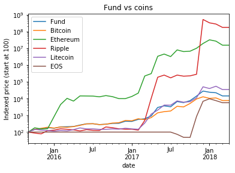

```python
date = '2015-09'
coins = ['Bitcoin', 'Ethereum', 'Ripple', 'Litecoin', 'EOS']
fund_vs_coins(date, coins)
plt.title('Fund vs coins')
plt.ylabel('Indexed price (start at 100)')
```

```python
assert b.T.sum().median() == 10
# check it looks ok
#b.T.sum().plot()
#plt.xlabel('Nr of coins in the fund')
#plt.show()
```

```python
# first date where nr of coins are 10
b[b.T.sum()==10].index.min()
```

```
Timestamp('2013-05-31 00:00:00', freq='M')
```

## Summary statistics

Return, Vol, Return/Vol, etc.

```python
fundmean = fundret.mean()*12
fundvol = fundret.std()*np.sqrt(12)
fundmean / fundvol
```

```
0.76927925165747768
```

```python
print("Annualized mean:", fundmean*100, "%",
      "Annualized vol:", fundvol*100, "%",
     "(Based on monthly data.)")
```

```
Annualized mean: 182.68070964828541 % Annualized vol: 237.469955487 % (Based on monthly data.)
```

```python
# day with max return
fundret.idxmax(), fundret[fundret.idxmax()]
```

```
(Timestamp('2013-11-30 00:00:00', freq='M'), 4.9421235970540174)
```

```
Text(0.5,0,'Monthly return (not annualized)')
```

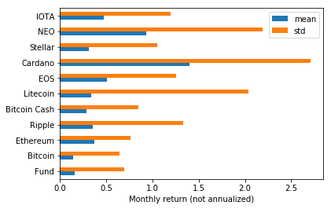

```python
rr = pd.concat([fundret, r[coins_top10]], axis=1)
rr.replace(0, np.nan).apply([np.mean, np.std]).T.plot.barh()
plt.xlabel('Monthly return (not annualized)')
```

```python
def sharpe(returnseries):
    # with risk free = 0
    # which does not matter since we compare among coins and their rf is arguably the same, although unknown
    return 12*np.mean(returnseries)/(np.sqrt(12)*np.std(returnseries))
```

```python
for coin in coins_top10:
    print(coin, sharpe(r[coin]))
print('Fund', sharpe(fundret))
```

```
Bitcoin 0.767623424326
Ethereum 1.1632170063
Ripple 0.880264648297
Bitcoin Cash 0.429305877471
Litecoin 0.561919039325
EOS 0.503223929962
Cardano 0.504707330117
Stellar 0.864996722331
NEO 0.783967387339
IOTA 0.520429029583
Fund 0.775771174783
```

## Returns

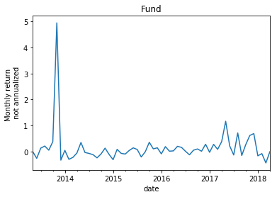

```python
fundret.plot()
plt.title('Fund')
plt.ylabel('Monthly return \n not annualized')
plt.show()
```

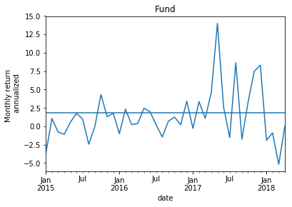

```python
fundret_annualized = 12*fundret
fundret_annualized.loc['2015':].plot()
plt.title('Fund')
plt.ylabel('Monthly return \n annualized')
plt.axhline(y=fundret_annualized.mean())
plt.show()
```

## Which coins are included?

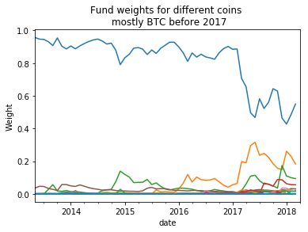

```python
w[coins_infund].plot(legend=False)
plt.title('Fund weights for different coins \n mostly BTC before 2017')
plt.ylabel('Weight')
plt.show()
# todo make a stacked bar chart
```

```python
k = 10
```

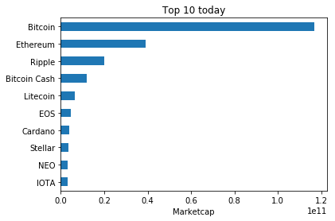

```python
# current top 10
mcap_mat.iloc[-2,:].sort_values(ascending=True).tail(k).plot.barh()
plt.title('Top ' + str(k) + ' today')
plt.xlabel('Marketcap')
plt.show()
```

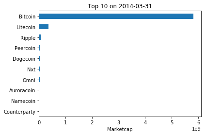

```python
# top k on a certain date
date = '2014-03-31'
mcap_mat.loc[date,:].sort_values(ascending=True).tail(k).plot.barh()
plt.title('Top ' + str(k) + ' on ' + date)
plt.xlabel('Marketcap')
plt.show()
```

## Correlations

```python
def corrplot(corr):
    # Generate a mask for the upper triangle
    mask = np.zeros_like(corr, dtype=np.bool)
    mask[np.triu_indices_from(mask)] = True

    # Set up the matplotlib figure
    f, ax = plt.subplots(figsize=(11, 9))

    # Generate a custom diverging colormap
    cmap = sns.diverging_palette(220, 10, as_cmap=True)

    # Draw the heatmap with the mask and correct aspect ratio

    return sns.heatmap(corr, mask=mask, cmap=cmap, vmax=.3, center=0,
                square=True, linewidths=.5, cbar_kws={"shrink": .5})
```

```python
start_date = '2015-03'
end_date = '2018-03'
```

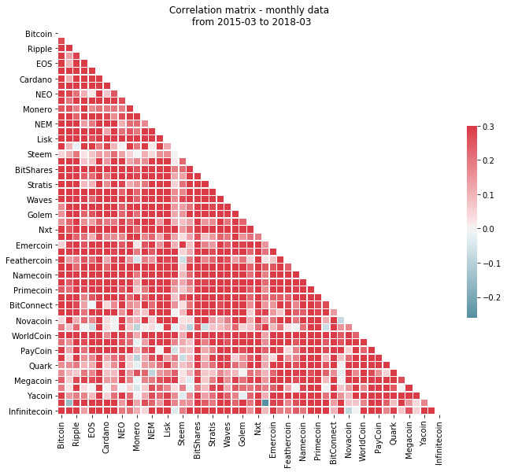

```python
# todo compute rolling corr matrix and plot
corrplot(corr=r[coins_infund].loc[start_date:end_date].corr())
plt.title('Correlation matrix - monthly data \n from ' + start_date + ' to ' + end_date)
plt.show()
```

```python
rr.head(3)
```

| date | Fund | Bitcoin | Ethereum | Ripple | Bitcoin Cash | Litecoin | EOS | Cardano | Stellar | NEO | IOTA |
| --- | --- | --- | --- | --- | --- | --- | --- | --- | --- | --- | --- |
| 2013-05-31 | 0.000000 | 0.000000 | 0.0 | 0.0 | 0.0 | 0.000000 | 0.0 | 0.0 | 0.0 | 0.0 | 0.0 |
| 2013-06-30 | -0.255678 | -0.262422 | 0.0 | 0.0 | 0.0 | -0.060606 | 0.0 | 0.0 | 0.0 | 0.0 | 0.0 |
| 2013-07-31 | 0.135031 | 0.136316 | 0.0 | 0.0 | 0.0 | 0.075269 | 0.0 | 0.0 | 0.0 | 0.0 | 0.0 |

```
Text(0.5,1,'Correlation matrix - monthly data \n from 2015-03 to 2018-03')
```

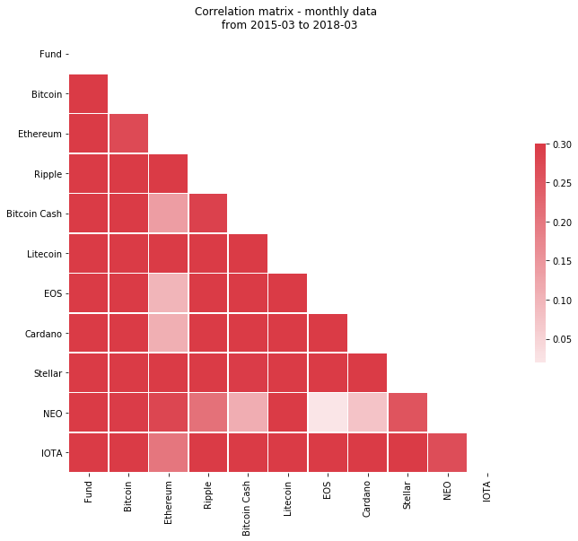

```python
corrplot(rr.loc[start_date:].corr())
plt.title('Correlation matrix - monthly data \n from ' + start_date + ' to ' + end_date)
```

```python
np.round(rr.loc[start_date:].corr(), 2)
```

|  | Fund | Bitcoin | Ethereum | Ripple | Bitcoin Cash | Litecoin | EOS | Cardano | Stellar | NEO | IOTA |
| --- | --- | --- | --- | --- | --- | --- | --- | --- | --- | --- | --- |
| Fund | 1.00 | 0.91 | 0.52 | 0.59 | 0.54 | 0.64 | 0.41 | 0.44 | 0.78 | 0.40 | 0.60 |
| Bitcoin | 0.91 | 1.00 | 0.27 | 0.33 | 0.58 | 0.50 | 0.36 | 0.30 | 0.55 | 0.30 | 0.58 |
| Ethereum | 0.52 | 0.27 | 1.00 | 0.36 | 0.14 | 0.35 | 0.10 | 0.11 | 0.50 | 0.28 | 0.20 |
| Ripple | 0.59 | 0.33 | 0.36 | 1.00 | 0.29 | 0.74 | 0.49 | 0.79 | 0.79 | 0.21 | 0.40 |
| Bitcoin Cash | 0.54 | 0.58 | 0.14 | 0.29 | 1.00 | 0.40 | 0.85 | 0.62 | 0.30 | 0.11 | 0.86 |
| Litecoin | 0.64 | 0.50 | 0.35 | 0.74 | 0.40 | 1.00 | 0.41 | 0.55 | 0.53 | 0.38 | 0.47 |
| EOS | 0.41 | 0.36 | 0.10 | 0.49 | 0.85 | 0.41 | 1.00 | 0.83 | 0.43 | 0.02 | 0.65 |
| Cardano | 0.44 | 0.30 | 0.11 | 0.79 | 0.62 | 0.55 | 0.83 | 1.00 | 0.55 | 0.08 | 0.62 |
| Stellar | 0.78 | 0.55 | 0.50 | 0.79 | 0.30 | 0.53 | 0.43 | 0.55 | 1.00 | 0.26 | 0.32 |
| NEO | 0.40 | 0.30 | 0.28 | 0.21 | 0.11 | 0.38 | 0.02 | 0.08 | 0.26 | 1.00 | 0.27 |
| IOTA | 0.60 | 0.58 | 0.20 | 0.40 | 0.86 | 0.47 | 0.65 | 0.62 | 0.32 | 0.27 | 1.00 |

```
Text(0.5,1,'Correlation matrix - daily data \n from 2015-03 to 2018-03')
```

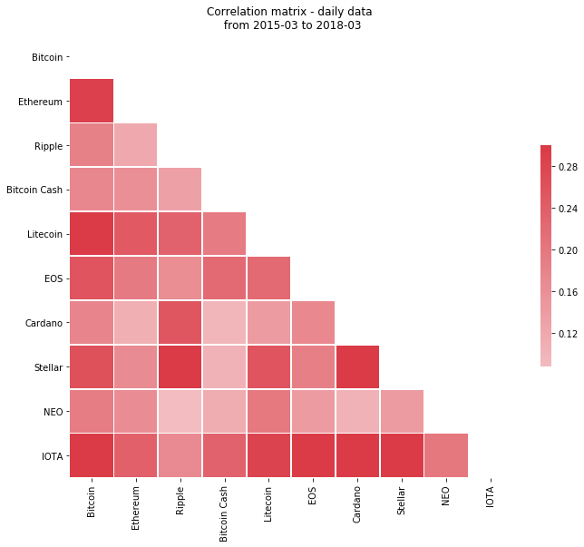

```python
r_top10_mat = returns_calc(daily_price_mat[coins_top10])
corr_top10daily = r_top10_mat.loc[start_date:].corr()
corrplot(corr_top10daily)
plt.title('Correlation matrix - daily data \n from ' + start_date + ' to ' + end_date)
```

```python
np.round(corr_top10daily, 2)
```

|  | Bitcoin | Ethereum | Ripple | Bitcoin Cash | Litecoin | EOS | Cardano | Stellar | NEO | IOTA |
| --- | --- | --- | --- | --- | --- | --- | --- | --- | --- | --- |
| Bitcoin | 1.00 | 0.29 | 0.18 | 0.18 | 0.50 | 0.26 | 0.18 | 0.26 | 0.19 | 0.37 |
| Ethereum | 0.29 | 1.00 | 0.12 | 0.16 | 0.25 | 0.20 | 0.11 | 0.17 | 0.17 | 0.24 |
| Ripple | 0.18 | 0.12 | 1.00 | 0.13 | 0.23 | 0.16 | 0.25 | 0.47 | 0.09 | 0.17 |
| Bitcoin Cash | 0.18 | 0.16 | 0.13 | 1.00 | 0.19 | 0.22 | 0.10 | 0.10 | 0.11 | 0.23 |
| Litecoin | 0.50 | 0.25 | 0.23 | 0.19 | 1.00 | 0.22 | 0.14 | 0.26 | 0.20 | 0.28 |
| EOS | 0.26 | 0.20 | 0.16 | 0.22 | 0.22 | 1.00 | 0.17 | 0.19 | 0.14 | 0.31 |
| Cardano | 0.18 | 0.11 | 0.25 | 0.10 | 0.14 | 0.17 | 1.00 | 0.30 | 0.11 | 0.31 |
| Stellar | 0.26 | 0.17 | 0.47 | 0.10 | 0.26 | 0.19 | 0.30 | 1.00 | 0.14 | 0.30 |
| NEO | 0.19 | 0.17 | 0.09 | 0.11 | 0.20 | 0.14 | 0.11 | 0.14 | 1.00 | 0.20 |
| IOTA | 0.37 | 0.24 | 0.17 | 0.23 | 0.28 | 0.31 | 0.31 | 0.30 | 0.20 | 1.00 |

```python
# todo compute rolling corr matrix and plot
```

## market cap covered by the fund

see the function for how `fundmcap` was created

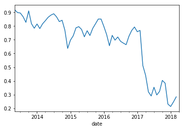

```python
totmcap = mcap_mat.T.sum()
fund_fraq_mcap = fundmcap / totmcap
fund_fraq_mcap.plot()
```

todo: ser lågt ut. är det verkligen rätt? borde vara 1.00 i början. ok att det är lågt i slutet för det är 1500 coins men början är ag tveksam till.

```python
top5_lastmcap = mcap_mat.loc['2018-03', coins_comp].sum().sum()
```

```python
fund_lastmcap = fundmcap.loc['2018-03'].sum()
```

```python
# helt klart ngt fel att top5 har mer i mcap än fonden.
# svar: det är för att du applicerar vikter W. om du applicerar binary matrix B så blir dom mer lika.
top5_lastmcap, fund_lastmcap, top5_lastmcap/fund_lastmcap
```

```
(182324790000.0, 74398855776.96608, 2.4506397053548215)
```

```python
# todo: nej inte ens då blev det rätt. vafan?
fundmcap_binary.loc['2015-03']
```

```
date
2015-03-31    3.887098e+09
Freq: M, dtype: float64
```

```python
182324790000.0 / 1e9 # 182 vs 3 dafuq
```

```
182.32479
```

## market cap for top 5 coins over time

it is not sufficient to hold only btc and eth to capture the market

```
Text(0,0.5,'Market cap in $')
```

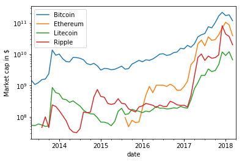

```python
mcap_mat[coins_comp].plot(logy=True)
plt.ylabel('Market cap in $')
```

## 3). Number of coins that has been in top 10 that today is out of top 50 and top 100 last 5 years

```python
# last day is -2
coins_mcap_today = mcap_mat.iloc[-2]
coins_mcap_today = coins_mcap_today.sort_values(ascending=False)
```

```python
# coins that are out of top 50 today
coins_mcap_today[50:].index
```

```
Index(['Aion', 'Ardor', 'Loopring', 'IOStoken', 'XPA', 'QASH', 'PIVX',
       'KuCoin Shares', 'Cryptonex', 'Ark',
       ...
       'Bubble', 'MSD', 'COMSA [XEM]', 'ODEM', 'STEX', 'InvestDigital',
       'Sphre AIR ', 'Pundi X', 'TechShares', 'W3Coin'],
      dtype='object', length=1512)
```

```python
# coins that has once been in the fund
len(coins_infund)
```

```
51
```

```python
intersection = set(coins_mcap_today[50:].index) & set(coins_infund)
len(intersection)
```

```
27
```

```python
print(len(coins_infund), "different coins has been in top 10. Out of these,",
      len(intersection),"are now outside top 50." )
```

```
51 different coins has been in top 10. Out of these, 27 are now outside top 50.
```

## 14). Number of in & outs in index (5 years)

```python
b_vs_bshift = b.shift(1) != b
fund_nr_coinswitches = b_vs_bshift.T.sum()
fund_nr_coinswitches = fund_nr_coinswitches[1:] # delete first row
```

The more coinswitches the harder it would be to replicate the portfolio on your own.

```
Text(0,0.5,'Coin switches')
```

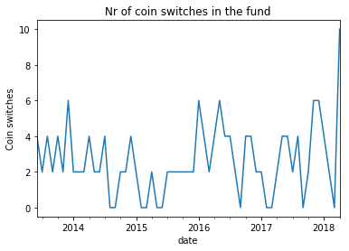

```python
fund_nr_coinswitches.plot()
plt.title('Nr of coin switches in the fund')
plt.ylabel('Coin switches')
```

```python
print("Nr of months with a coin switch:", sum(fund_nr_coinswitches > 0), "out of", len(fund_nr_coinswitches))
print("Median coins switches during a month:", fund_nr_coinswitches.median())
```

```
Nr of months with a coin switch: 48 out of 59
Median coins switches during a month: 2.0
```

```python
print("example of a shift: NEM out, IOTA in")
print(b[b>0].iloc[-3,].sort_values()[0:11])
print(b[b>0].iloc[-4,].sort_values()[0:11])
```

```
example of a shift: NEM out, IOTA in
Bitcoin         1.0
Ethereum        1.0
Ripple          1.0
Bitcoin Cash    1.0
EOS             1.0
Litecoin        1.0
Cardano         1.0
Stellar         1.0
NEO             1.0
IOTA            1.0
Monero          NaN
Name: 2018-02-28 00:00:00, dtype: float64
Bitcoin         1.0
Ethereum        1.0
Ripple          1.0
Bitcoin Cash    1.0
EOS             1.0
Litecoin        1.0
Cardano         1.0
Stellar         1.0
NEO             1.0
NEM             1.0
IOTA            NaN
Name: 2018-01-31 00:00:00, dtype: float64
```

```python
b.loc['2017-11']
```

| date | Bitcoin | Ethereum | Ripple | Bitcoin Cash | EOS | Litecoin | Cardano | Stellar | NEO | IOTA | ... | LLToken | Dutch Coin | Infinitecoin | Karmacoin | VPNCoin | Trinity | Happy Creator Coin | MergeCoin | TimesCoin | W3Coin |
| --- | --- | --- | --- | --- | --- | --- | --- | --- | --- | --- | --- | --- | --- | --- | --- | --- | --- | --- | --- | --- | --- |
| 2017-11-30 | 1 | 1 | 1 | 1 | 0 | 1 | 0 | 0 | 0 | 1 | ... | 0 | 0 | 0 | 0 | 0 | 0 | 0 | 0 | 0 | 0 |

1 rows × 1562 columns

## position changes

begin with: delta weights. because this tells you how much there is to rebalance

```
Text(0.5,1,'Total weight change per month')
```

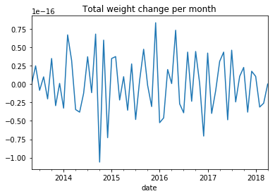

```python
w_change = w - w.shift(1)
w_change[coins_infund].T.sum().plot()
plt.title('Total weight change per month')
```

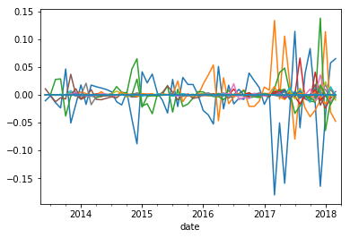

```python
w_change = w - w.shift(1)
w_change[coins_infund].plot(legend=False)
```

```
Text(0.5,1,'Sum of weight changes')
```

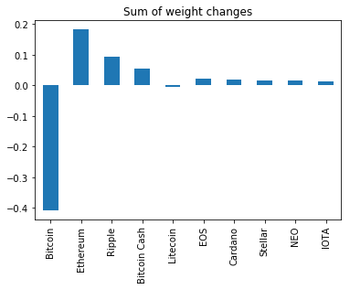

```python
w_change[coins_top10].sum().plot.bar()
plt.title('Sum of weight changes')
```

Logisk output: över tid så har dom som ligger i top 10 ätit sig in i fonden, på bekostnad av btc.